# Projet 2 : VaR et backtesting, Action UNH

## 2.2) VaR Conditionnelle :

Dans cette partie, nous allons estimer la VaR du modèle EGARCH(1,1) ~ std : La justification du choix des distributions et des modèles est donnée en annexe.

- Choix des distributions
- Annexe
- Le modèle EGARCH est défini en annexe ici.
- Le modèle est estimé ici.

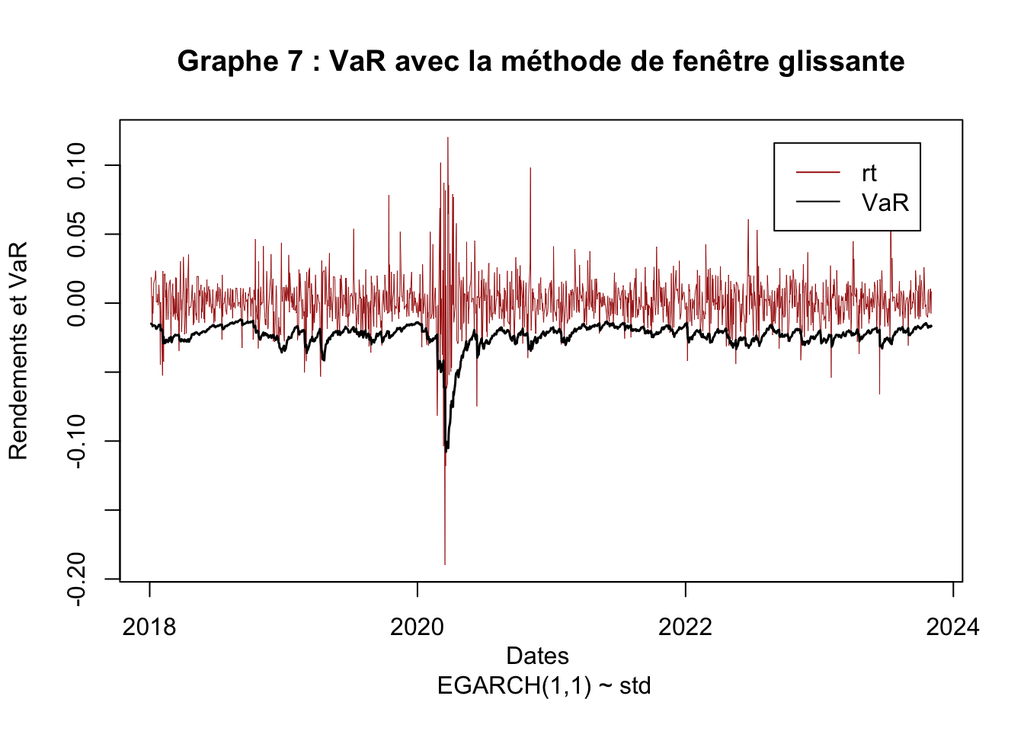

Table 2 : Violations VaR EGARCH(1,1)

|  | Violation Estimée | Violation théorique | PV Kupiec | PV Christoffersen |
| --- | --- | --- | --- | --- |
| VaR EGARCH(1,1) ~ std | 91 | 73.4 | 0.041 | 0.047 |

La VaR de notre modèle EGARCH présente un taux de violation de 6,2%. Nous avons donc sous-évalué la VaR de 1,2%. La p-value est inférieure à 0,05 dans le cadre du test de Kupiec. Ainsi, nous rejetons H0, indiquant que la VaR n’est pas bien estimée. De même, la p-value est inférieure à 0,05 dans le cadre du test de Christoffersen, conduisant également au rejet de H0. La VaR n’est donc une fois de plus pas bien estimée selon ce test.

# 3) Conclusions:

Table 3 : Récapitulatif des VaR

|  | Violation Théorique | Violation Estimée | PV Kupiec | PV Christoffersen |
| --- | --- | --- | --- | --- |
| VaR Normale | 73 | 84 | 0.214205398 | 0.0151087915 |
| VaR Cornish-Fisher | 73 | 102 | 0.001183107 | 0.0004918278 |
| VaR Historique | 73 | 102 | 0.001183107 | 0.0004918278 |
| VaR EGARCH(1,1) ~ std | 73.4 | 91 | 0.041 | 0.047 |

Aucune des VaR valident les deux tests de Kupiec et de Christoffersen. Celle qui a se rapproche le plus de des violations théorique est le VaR Normale.

Une piste de recherche aurait été de répartir $r_t$ en trois ensembles distincts : un ensemble d’entraînement, un ensemble de validation, et un ensemble de test. Cette approche aurait permis d’estimer plusieurs modèles sur l’ensemble de test, comme démontré ici, d’évaluer plusieurs valeurs à risque (VaR) sur l’ensemble de validation, comme présenté dans la section E) D’autres VaR Conditionnelle :, et enfin de sélectionner le modèle qui aurait donné la meilleure estimation de la VaR sur l’ensemble de validation et le tester sur l’ensemble restant, l’ensemble de test.

Bien que cette méthode soit couramment utilisée en apprentissage supervisé, il serait judicieux de se référer à des articles spécialisés, étant donné que les séries temporelles constituent un type de données particulier pour lequel cette méthodologie pourrait ne pas être parfaitement adaptée.